# Ejercicio Práctico 2

###Pregunta E) Ahora realice el mismo gráfico pero agrupando las líneas según continente (diferenciado por color). Utilizando gganimate , genere un gif este gráfico realizando una transición por año . (3 puntos)

```r
library(gganimate)
library(gifski)
library(png)
library(av)

p <- terrorismo |>
  mutate(iyear = as.numeric(as.character(iyear))) |>
  group_by(iyear) |>
  count(continente) |>
  ggplot(aes(x = iyear, y = n, color = continente)) +
  geom_line() +
  scale_x_log10() +
  labs(title = "Evolución del número de ataques terroristas según continente",
       x = "Año", y = "Número de Incidentes") +
  transition_reveal(iyear)

#Para hacer gift primero se instalan gganimate, gifski, png, av
#luego se define p en función a la tabla realizada anteriormente
#Por último, se define la transición, en este caso se hace por años
view (p)
```

[output not shown]

###Pregunta F) Además de presentarlo en el HTML, guarde el gif , con apellido_nombre.gif y adjúntelo en su entrega. (2 punto)

```r
anim_save("C:/Users/antua/Documents/Rstudio/Vera_Antuane.gif", animation = p)
```

```
## `geom_line()`: Each group consists of only one observation.
## ℹ Do you need to adjust the group aesthetic?
## `geom_line()`: Each group consists of only one observation.
## ℹ Do you need to adjust the group aesthetic?
```

##Pregunta 2 AML.xlsx es una data que brinda distintos indicadores/índices a nivel global. Responda lo siguiente:

###Pregunta A) Genere un gráfico de dispersión entre las variables Pobreza y CPI_Index .

```r
library(readxl)
AML <- read_excel("AML.xlsx")
View(AML)
```

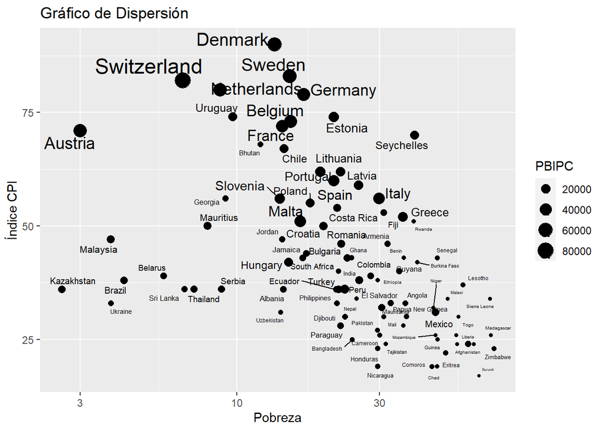

```r
library(ggrepel)
AML |>
  ggplot(aes(x = Pobreza, y = CPI_Index, size = PBIPC, label = Pais)) +
  geom_point() +
  scale_x_log10() +
  labs(title = "Gráfico de Dispersión", x = "Pobreza", y = "Índice CPI") +
  geom_text_repel(max.overlaps = 10)
```

Agregue las siguientes características: a. Que el tamaño del punto esté vinculado con el PBIPC (PBI per cápita) del país. b. Agregue nombre a los ejes X e Y. c. Etiquete los puntos con el nombre de cada país. Utilice un etiquetado para los puntos de tal forma que se evite la superposición de estas etiquetas. d. Coloque título al gráfico (Sólo el título, no subtítulo). (3 puntos)

###Pregunta B)  
Para mejorar la visualización del gráfico anterior aplique facetas por continente. ¿Qué relación puede identificar en estas variables, cambia algo de continente en continente? (2 puntos)

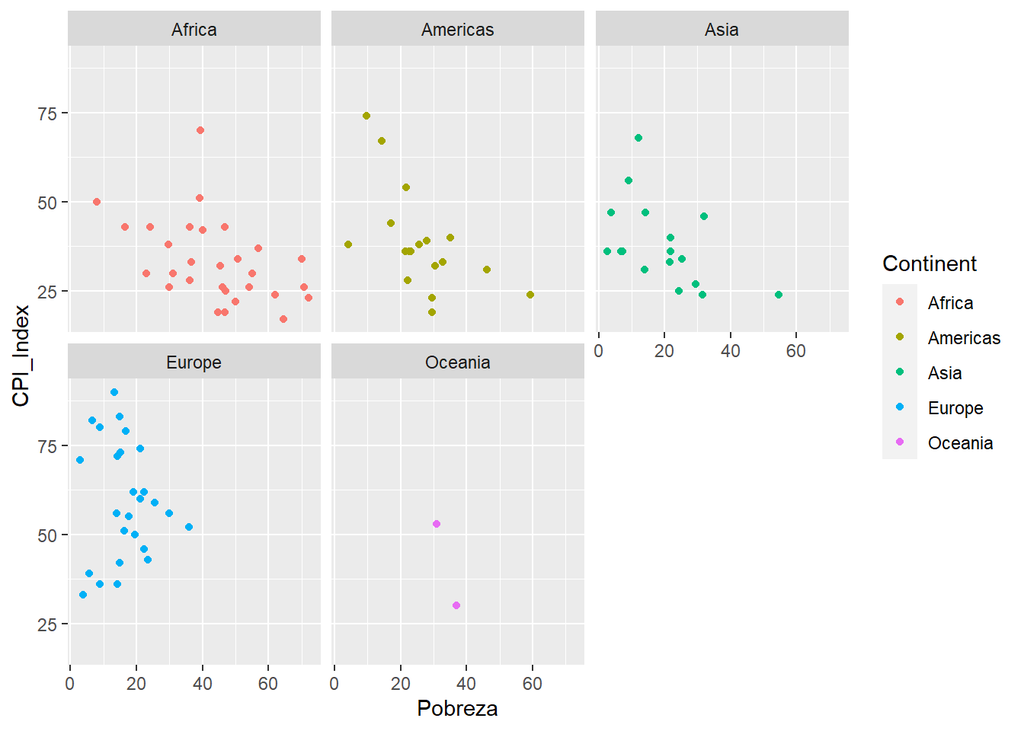

```r
AML %>%
  ggplot() +
  aes(x = Pobreza) +
  aes(y = CPI_Index) +
  geom_point() +
  aes(color=Continent) +
  facet_wrap(~Continent)  #<<
```

###Pregunta C) Genere un boxplot de la variable AML_Index según continente (cada continente con un color). En el mismo gráfico, calcule la media del Índice en cada continente (stat_summary) y grafíquelo con un punto rojo en cada boxplot. Interprete. (2 puntos)

```r
summary(AML$AML_Index)
```

```
##    Length     Class      Mode
##        95 character character
```

```r
class(AML$AML_Index)
```

```
## [1] "character"
```

```r
AML$AML_Index = as.numeric(AML$"AML_Index")
summary(AML$AML_Index)
```

```
##    Min. 1st Qu.  Median    Mean 3rd Qu.    Max.    NA's
##   3.000   4.605   5.160   5.261   5.835   8.140      16
```

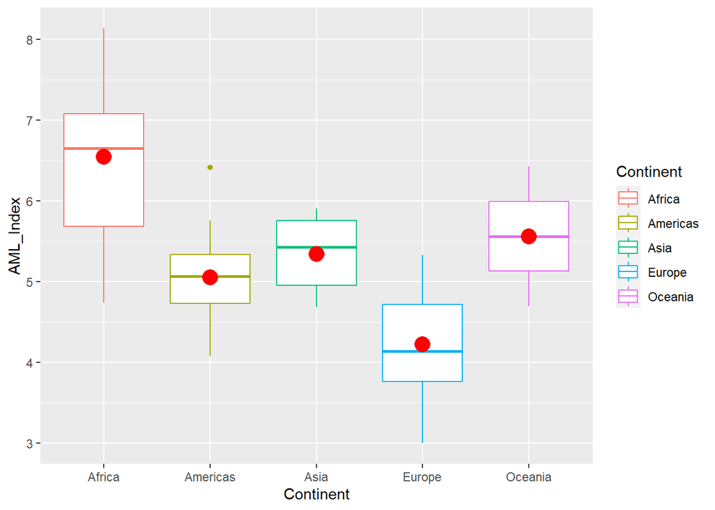

```r
AML %>%
  ggplot()+
  aes(x=Continent)+ aes(y=AML_Index) +
  aes(color=Continent) +
  geom_boxplot()+
  stat_summary(fun ="mean",  #<<
               colour="red",  #<<
               size = 5,  #<<
               geom="point")   #<<
```